# Insights into Prenatal Care in Cambodia

Yasmine Illi

2026-07-28

## Aim of this analysis

In this report we are going to evaluate the status of prenatal care in Cambodia. For this purpose we are going to be using the DHS data set from 2013. The primary aim is to evaluate the proportion of women with access to prenatal care. A secondary aim is to evaluate whether there is an effect of wealth and health insurance on access to prenatal care.

Variables will include:

- General sociodemographic variables e.g. age, wealth, health insurance, number of children
- Care provider of prenatal care
- Measurements undertaken during prenatal visits

The DHS data set collects data on prenatal care of different pregnancies. For simplicity, we are going to focus only on the pregnancy index 1.

The following report will first give a general overview of the data set in regards to pregnancy and number of children, as well as an insight into how wealth status and having health insurance are correlated.

## General demographics

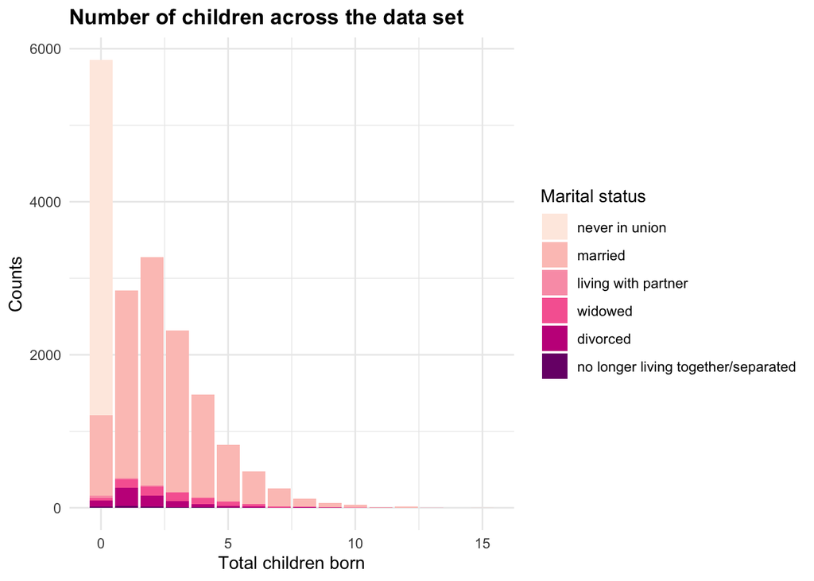

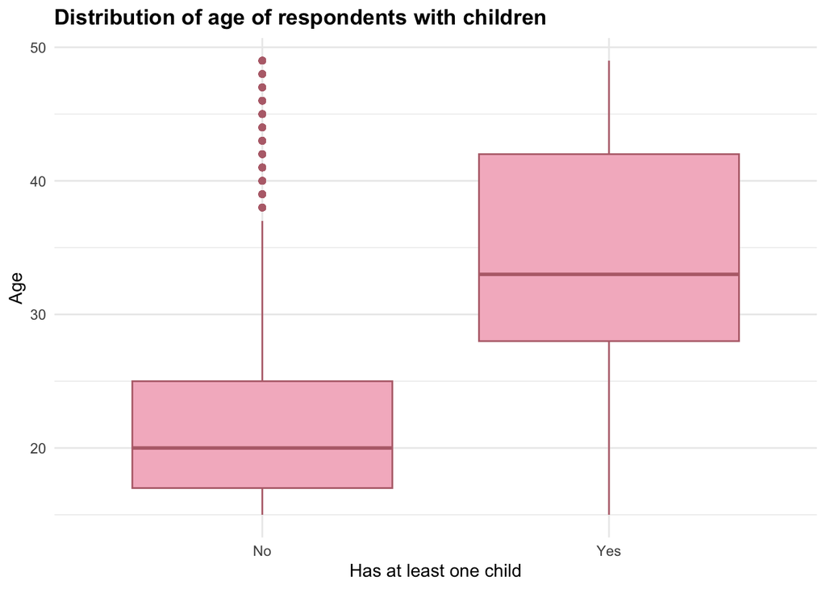

Although the age range of women with children and without children is very similar, this graph shows very well that the median age of women without children is a lot lower than women with children (20 vs 33).

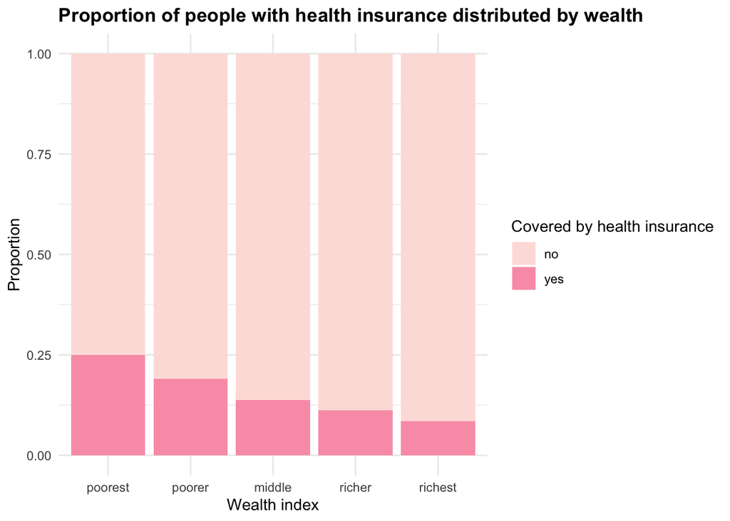

Another factor that is important when evaluating prenatal care is the wealth status of women. We will evaluate if wealth influences access to prenatal care later but for now we will just look at the insurance status of women in relation to their wealth status. Surprisingly, as wealth goes up, the proportion of women with health insurance goes down. Possible explanations for this could be:

- The richer the woman, the more she can afford to pay medical bills without insurance.
- Insurance might only cover very basic health care and if you can afford “better” treatments that are not covered by insurance, it doesn’t make sense to pay for the insurance.
- The poor might have higher medical needs, as poverty itself is a risk factor for many health conditions, so they might have higher medical costs. Therefore it might be less expensive to pay health insurance rather than pay their medical bills.
- There might be a health insurance program by the government that subsidizes health insurance for the poor.

It would definitely be interesting to dig into this further, but for now we will focus only on the aspects of wealth that might influence prenatal care.

## Prenatal visits

As shown above, a lot of women in this cohort do not have any children. In this section we are going to focus on the women that did have at least one child.

**Table 1. General demographics of women with at least one child**

| **Characteristic** | **N = 11,723**<sup>1</sup> |
| --- | --- |
| respondent's current age | 33 (28, 42) |
| age of respondent at 1st birth | 21.0 (19.0, 23.0) |
| highest educational level |  |
| no education | 1,918 (16%) |
| primary | 6,074 (52%) |
| secondary | 3,410 (29%) |
| higher | 321 (2.7%) |
| wealth index |  |
| poorest | 2,286 (20%) |
| poorer | 2,181 (19%) |
| middle | 1,930 (16%) |
| richer | 2,261 (19%) |
| richest | 3,065 (26%) |
| covered by health insurance | 1,794 (15%) |
| current marital status |  |
| never in union | 6 (<0.1%) |
| married | 10,525 (90%) |
| living with partner | 57 (0.5%) |
| widowed | 534 (4.6%) |
| divorced | 546 (4.7%) |
| no longer living together/separated | 55 (0.5%) |

<sup>1</sup> Median (Q1, Q3); n (%)

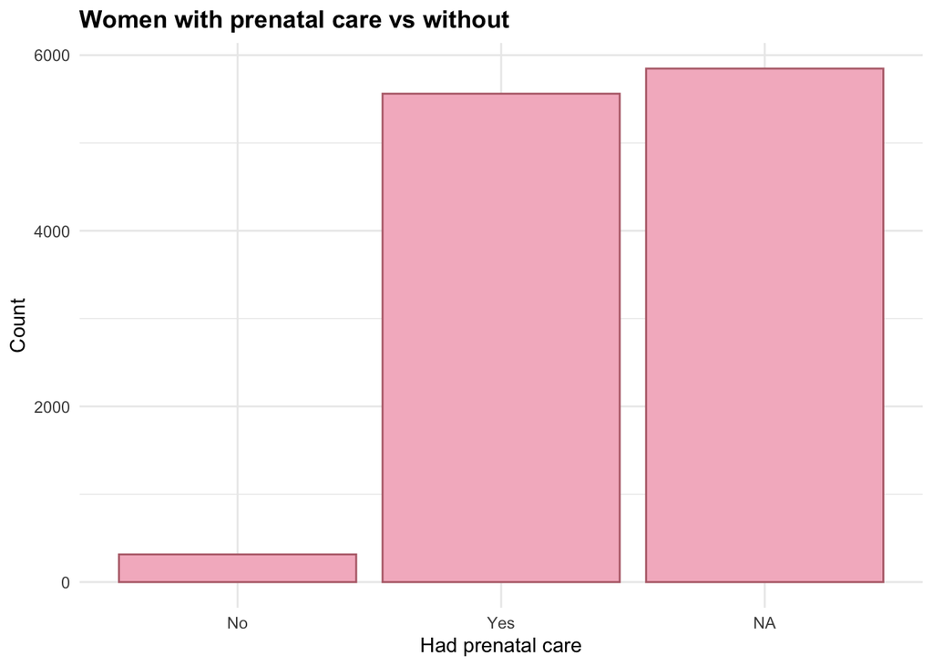

Of all the answers recorded, 94.6% of the women received prenatal care. Most NA values stem from the fact that not all women with children were asked if they had had prenatal care or not, however we still need to be cautious interpreting these results, since the NA values could potentially disguise or distort the real results. For the subsequent visualizations the NA values will not be shown.

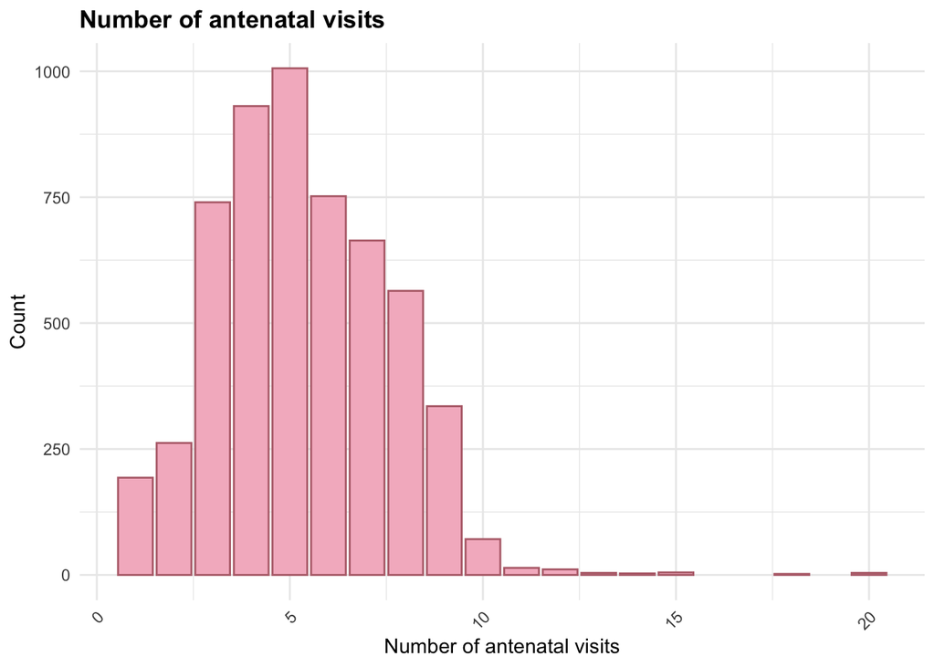

Most women had at least 3 prenatal visits. Now we want to find out, if the number of prenatal visits varies with wealth status and health insurance status.

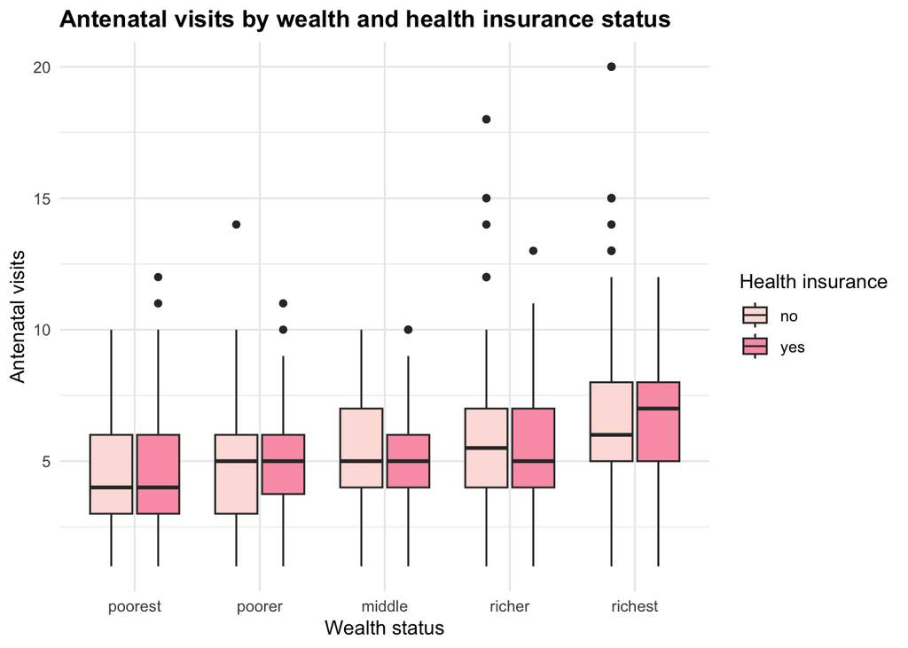

In general, higher wealth appears to be associated with a greater number of prenatal visits. Health insurance seems to have only a small association with the number of prenatal visits. As this is cross-sectional, descriptive data, these are associations rather than established causal effects.

Next, we are interested in who performs the prenatal visit.

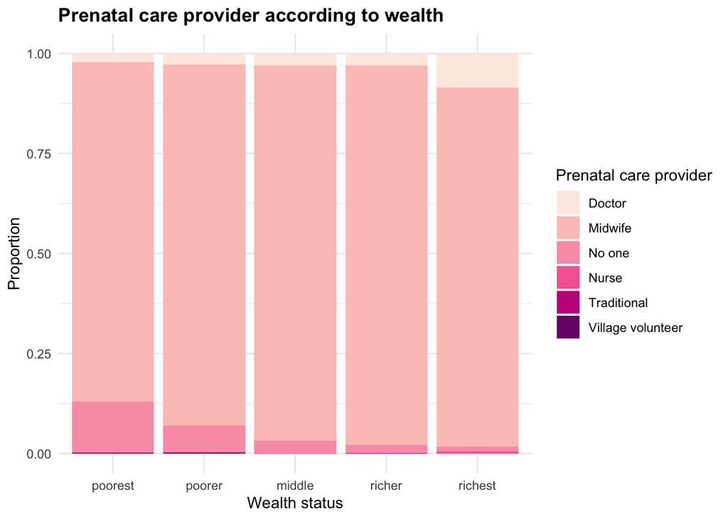

The majority of prenatal care is done by midwives, regardless of wealth status. However, with increasing wealth there is also an increasing number of doctors providing prenatal care and a decrease in the proportion receiving no care.

Finally, this table shows what the prenatal visit consisted of:

**Table 2. Components of antenatal care received**

| **Characteristic** | **N = 11,723**<sup>1</sup> |
| --- | --- |
| during pregnancy: height measured | 4,837 (87%) |
| Unknown | 6,137 |
| during pregnancy: blood pressure taken | 5,355 (96%) |
| Unknown | 6,137 |
| during pregnancy: urine sample taken | 2,735 (49%) |
| Unknown | 6,137 |
| during pregnancy: blood sample taken | 4,173 (75%) |
| Unknown | 6,137 |
| during pregnancy, given or bought iron tablets/syrup |  |
| no | 315 (5.3%) |
| yes | 5,580 (95%) |
| don't know | 4 (<0.1%) |
| Unknown | 5,824 |
| antenatal care: nutritional counseling | 4,858 (87%) |
| Unknown | 6,137 |
| told about pregnancy complications |  |
| no | 884 (16%) |
| yes | 4,670 (84%) |
| don't know | 32 (0.6%) |
| Unknown | 6,137 |
| during antenatal visit talked about: hiv transmitted mother to child |  |
| no | 943 (27%) |
| yes | 2,477 (71%) |
| don't know | 67 (1.9%) |
| Unknown | 8,236 |
| during antenatal visit talked about: things to do to prevent getting hiv |  |
| no | 1,006 (29%) |
| yes | 2,400 (69%) |
| don't know | 81 (2.3%) |
| Unknown | 8,236 |
| during antenatal visit talked about: getting tested for hiv |  |
| no | 633 (18%) |
| yes | 2,804 (80%) |
| don't know | 50 (1.4%) |
| Unknown | 8,236 |

<sup>1</sup> n (%)

We can see that most women had the most important markers of health measured during pregnancy and precautions towards HIV and iron deficiency taken or addressed. What is noticeable is that especially the markers that are easy to measure without much equipment, like height or blood pressure are well covered. Urine samples and blood samples would require more equipment to get the read-outs needed for screening or diagnosis of certain conditions in pregnancy. Therefore, the fact that these measurements are lower than others might be due to missing resources.

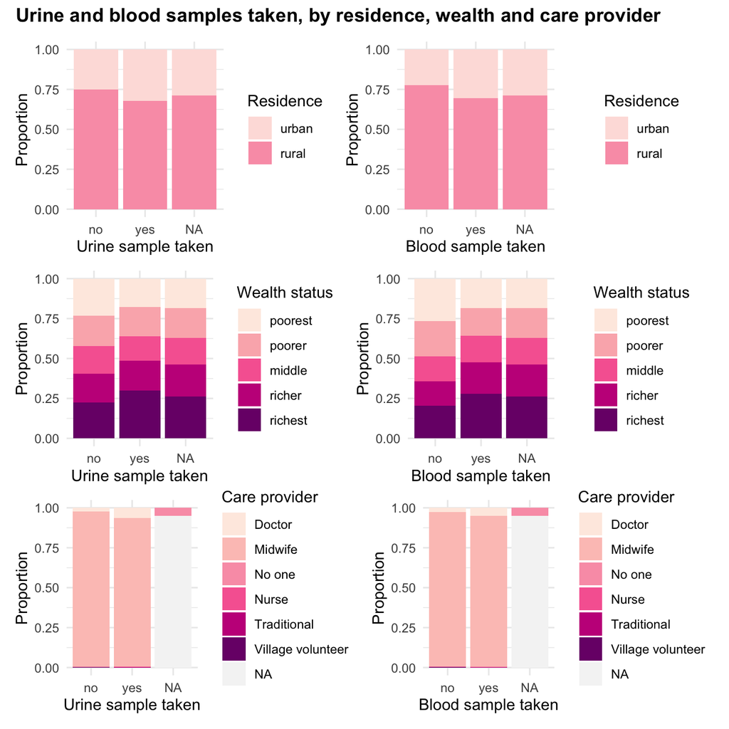

Place of residence, wealth and the type of care provider slightly affect if urine or blood samples were taken, however there is not as large of a gap as expected. Therefore other factors likely play a role in influencing whether blood or urine samples are taken during prenatal care, for instance religious or cultural beliefs.

## Conclusions

In conclusion we can say that most women in Cambodia received prenatal care with at least three visits before delivering their baby. Most of the prenatal care was done by midwives. There was a good coverage of what was being measured and discussed during the prenatal visits. Urine and blood samples were among the measurements that were being done the least and this is only in part associated with place of residence, wealth and the type of care provider.

As to whether wealth and health insurance influence access to prenatal care, wealth appears to be more strongly associated with access to prenatal care than health insurance coverage.

These findings should be interpreted with caution. They are based on cross-sectional, descriptive data, so the relationships described are associations rather than established causal effects. They are also limited to women with recorded prenatal data; the excluded NA group may differ systematically from those included, which could affect the results.